# TP2

# Exercice 1.

### Q1

$$\begin{aligned}
E(Y)&=E(X)=\frac{1}{6}=\sum_{Y\subset{1,0,-1}}Y*P(Y)\\
&=1*c+(-1)*(1-c-\frac{5}{6})+0*\frac{5}{6}=\frac{1}{6}\\
c&=\frac{1}{6}
\end{aligned}$$
Donc on $P(Y=1)=\frac{1}{6}$ et $P(Y=-1)=0$

### Q2

$$\begin{aligned}
E(Y^2)&=\sum_{Y\subset{1,0,-1}}Y^2*P(Y)\\
&=1^2*\frac{1}{6}+(-1)^2*(0)+0*\frac{5}{6}=\frac{1}{6}\\
Var(Y)&=E(Y^2)-(E(Y))^2\\
&=\frac{1}{6}-(\frac{1}{6})^2\\
&=\frac{5}{36}
\end{aligned}$$
#pourquoi Var Y < Var X# La probabilite que Y = -1 est nulle, on a donc moins de valeurs pour Y donc la variance est plus faible.

### Q3

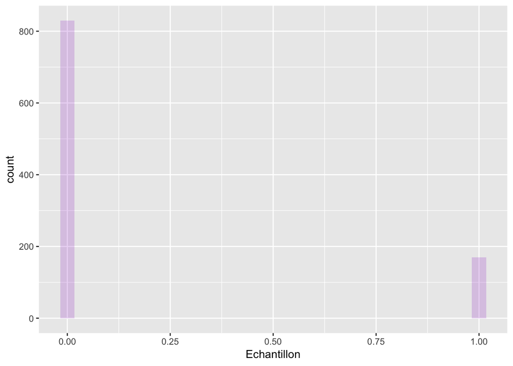

```r
simuY<-function(){
  X=c(0,1)
  P=c(5/6,1/6)
  C<-c(P[1])
    C<-c(C,C[1]+P[2])

  k<-1
  u<-runif(1,0,1)
  while(u>C[k]){
    k<-k+1
  }
  return (X[k])
}
N=1000
echantillonY=c()
for (i in 1:1000){
  echantillonY<-c(echantillonY,simuY())
}


dat <- data.frame(echantillonY)
plot1 <- ggplot(dat,aes(x=dat$echantillonY)) + geom_histogram(fill = "darkorchid", alpha = 0.2) + xlab("Echantillon")
plot1
```

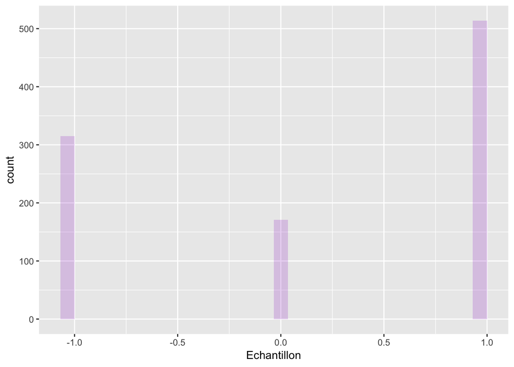

```r
simuX<-function(){
  X=c(-1,0,1)
  P=c(1/3,1/6,1/2)
  C<-c(P[1])
    C<-c(C,C[1]+P[2])
C<-c(C,C[2]+P[3])

  k<-1
  u<-runif(1,0,1)
  while(u>C[k]){
    k<-k+1
  }
  return (X[k])
}
N=1000
echantillonX=c()
for (i in 1:1000){
  echantillonX<-c(echantillonX,simuX())
}


dat2 <- data.frame(echantillonX)
plot2 <- ggplot(dat2,aes(x=dat2$echantillonX))+ geom_histogram(fill = "darkorchid", alpha = 0.2) + xlab("Echantillon")
plot2
```

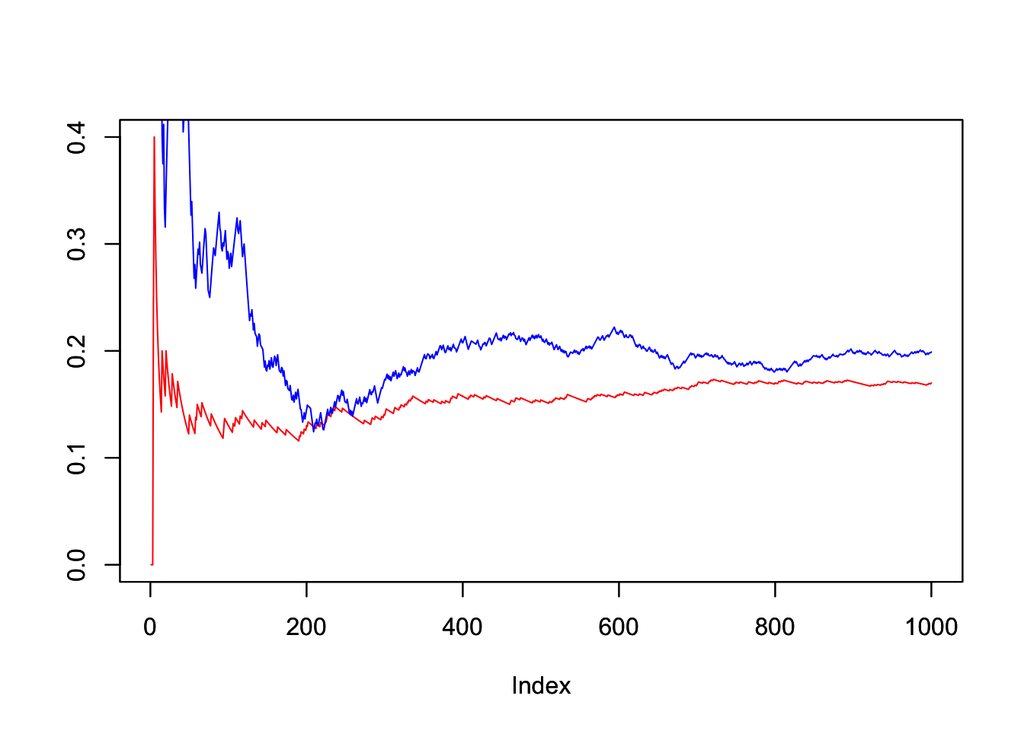

```r
Z_x=c()
for(i in 1:1000){
  Z_x=c(Z_x,mean(echantillonX[1:i]))
}
Z_y=c()
for(i in 1:1000){
  Z_y=c(Z_y,mean(echantillonY[1:i]))
}


plot(Z_y,ylim = c(0,0.4),type='line',col='red',ylab="")
par(new=TRUE)
plot(Z_x,ylim = c(0,0.4),type='line',col='blue',ylab="")
```

### Q4

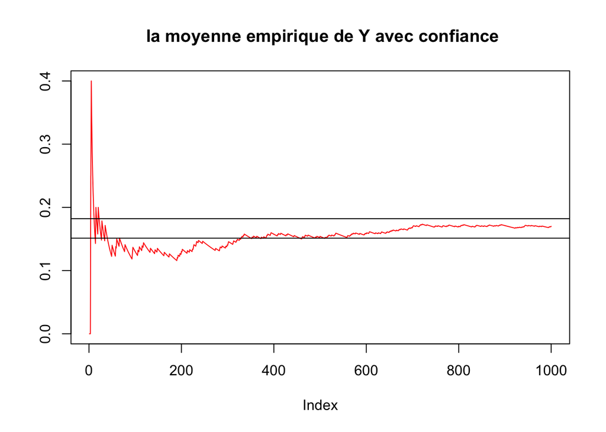

```r
alpha=0.05
c_alpha=qnorm(1-alpha/2)

Sny=0
for(i in 1:1000){
  Sny=Sny+echantillonY[i]^2+2*echantillonY[i]*Z_y[i]+Z_y[i]^2
}
Sny=Sny/999
epsY=c_alpha*Sny/sqrt(N)
plot(Z_y,ylim = c(0,0.4),type='line',col='red',ylab="",main=" la moyenne empirique de Y avec confiance")

abline(h=1/6 +epsY)
abline(h=1/6-epsY)
```

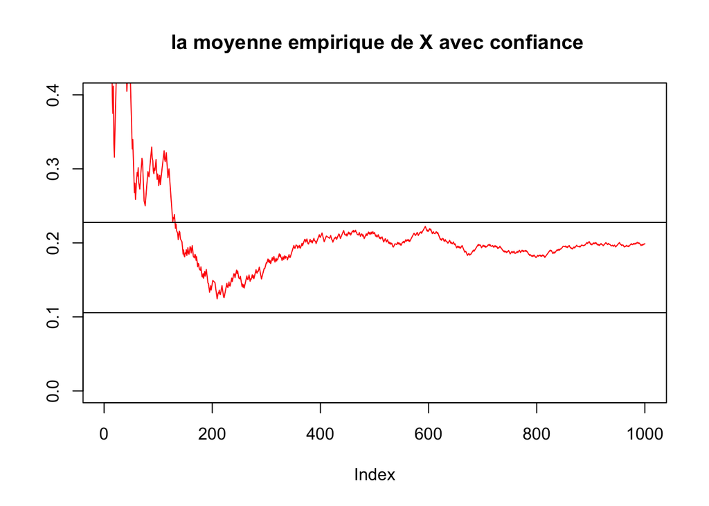

```r
alpha=0.05
c_alpha=qnorm(1-alpha/2)

Snx=0
for(i in 1:1000){
  Snx=Snx+echantillonX[i]^2+2*echantillonX[i]*Z_x[i]+Z_x[i]^2
}
Snx=Snx/999
epsX=c_alpha*Snx/sqrt(N)
plot(Z_x,ylim = c(0,0.4),type='line',col='red',ylab="",main=" la moyenne empirique de X avec confiance")

abline(h=1/6 +epsX)
abline(h=1/6-epsX)
```

```r
for(i in 1000:-1:1){
  d=0

  if(Z_y[i]<1/6 -epsY){

    d=i
    break
  }else if(Z_y[i]>1/6 +epsY){
    d=i
    break
  }

}
N0_y<-d
print("N0 d'echantillon y :")
```

```
## [1] "N0 d'echantillon y :"
```

```r
N0_y
```

```
## [1] 510
```

```r
for(i in 1000:-1:1){
  d=0

  if(Z_x[i]<1/6 -epsX){

    d=i
    break
  }else if(Z_x[i]>1/6 +epsX){
    d=i
    break
  }

}
N0_x<-d
print("N0 d'echantillon x:")
```

```
## [1] "N0 d'echantillon x:"
```

```r
N0_x
```

```
## [1] 131
```

```r
x<-rnorm(10000)
sum<-0
for(i in 1:10000){
  if(x[i]>=3.5){
    sum<-sum+x[i]
  }
}
esti<-sum/10000
esti
```

```
## [1] 0.001226544
```

### Q2

Tracer sur le meme graphe N->$\overline{Xn}$

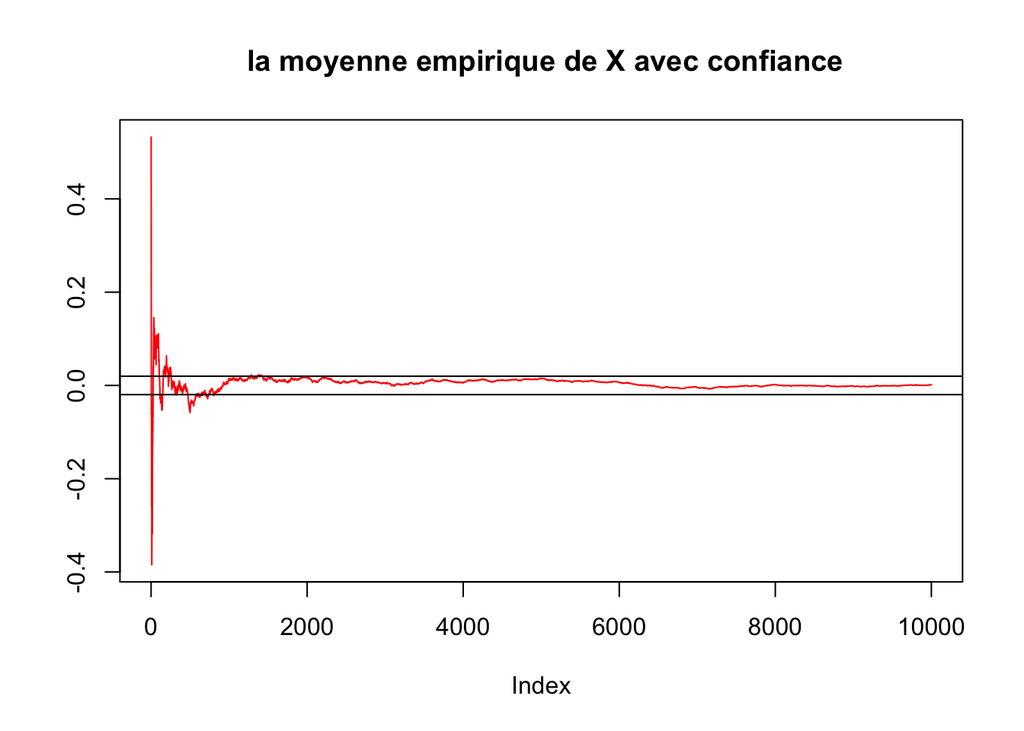

```r
alpha=0.05
c_alpha=qnorm(1-alpha/2)

Z_x=c()
for(i in 1:10000){
  Z_x=c(Z_x,mean(x[1:i]))
}

Snx=0
for(i in 1:10000){
  Snx=Snx+x[i]^2+2*x[i]*Z_x[i]+Z_x[i]^2
}
Snx=Snx/9999
epsX=c_alpha*Snx/sqrt(10000)
plot(Z_x,type='line',col='red',ylab="",main=" la moyenne empirique de X avec confiance")

abline(h=0 +epsX)
abline(h=0-epsX)
```

### Q3

(a)Identifiez la fonction $\psi$ tell que $E(g(x))=E(\psi(Z^{\mu}))$

Parce que $Z^{\mu}\sim N(\mu;1)$, $\psi(y)=(y-\mu)1_{y\ge\mu+3.5}$

(b)On pose $\mu=2.5$, pour N = 1000, puis pour N = 10000 par la méthode d’échantillonage préférentie

```r
p_x<-rnorm(1000,2.5,1)

sum<-0
for(i in 1:1000){
  if(p_x[i]>3.5){
  p_x[i]=exp(2.5*(2.5-2*p_x[i])/(2*1))

    sum<-sum+p_x[i]
  }
}
print('for N=1000:')
```

```
## [1] "for N=1000:"
```

```r
sum/1000
```

```
## [1] 0.0002010401
```

```r
p_x<-rnorm(10000,2.5,1)


sum<-0
for(i in 1:10000){
  if(p_x[i]>3.5){
  p_x[i]=exp(2.5*(2.5-2*p_x[i])/(2*1))

    sum<-sum+p_x[i]
  }
}
print('for N=10000:')
```

```
## [1] "for N=10000:"
```

```r
sum/10000
```

```
## [1] 0.000228293
```

(c)Pour N = 1, . . . , 10000, tracez sur le même graphe les fonctions N → $\frac{g(X1 )+...g(XN )}{N}$ et N → $\frac{\psi(Z1μ)+...\psi(ZNμ )}{N},$ pour μ = 2.5.

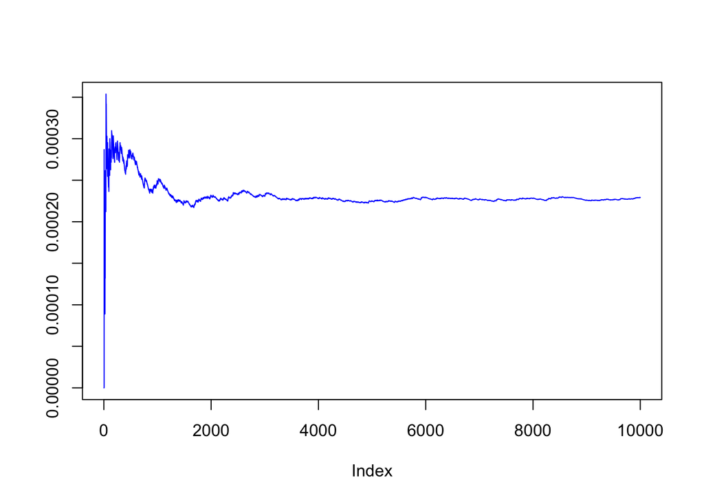

```r
p_x<-rnorm(10000,2.5,1)

sum<-0
for(i in 1:10000){
  if(p_x[i]>=3.5){
    p_x[i]=exp(2.5*(2.5-2*p_x[i])/(2*1))


  }else{
    p_x[i]=0
  }
}

Z_p=c()
for(i in 1:10000){
  Z_p=c(Z_p,mean(p_x[1:i]))
}

Z_x=c()
for(i in 1:10000){
  if(x[i]<3.5){
    x[i]=0
  }
  Z_x=c(Z_x,mean(x[1:i]))
}

plot(Z_p,type='line',col='blue',ylab="")
```

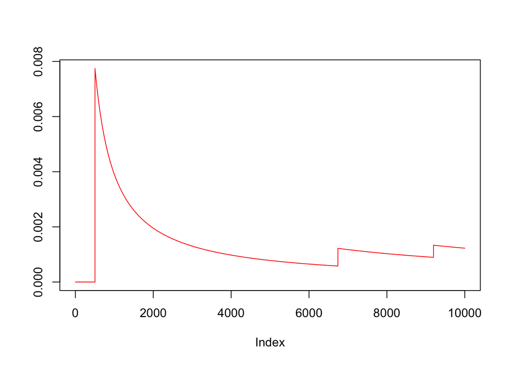

```r
plot(Z_x,type='line',col='red',ylab="")
```

On trouve que la simulation d’importance converge plus rapidement, elle a la plus petite variance.

4. faire un zoom pour 1,..,1000

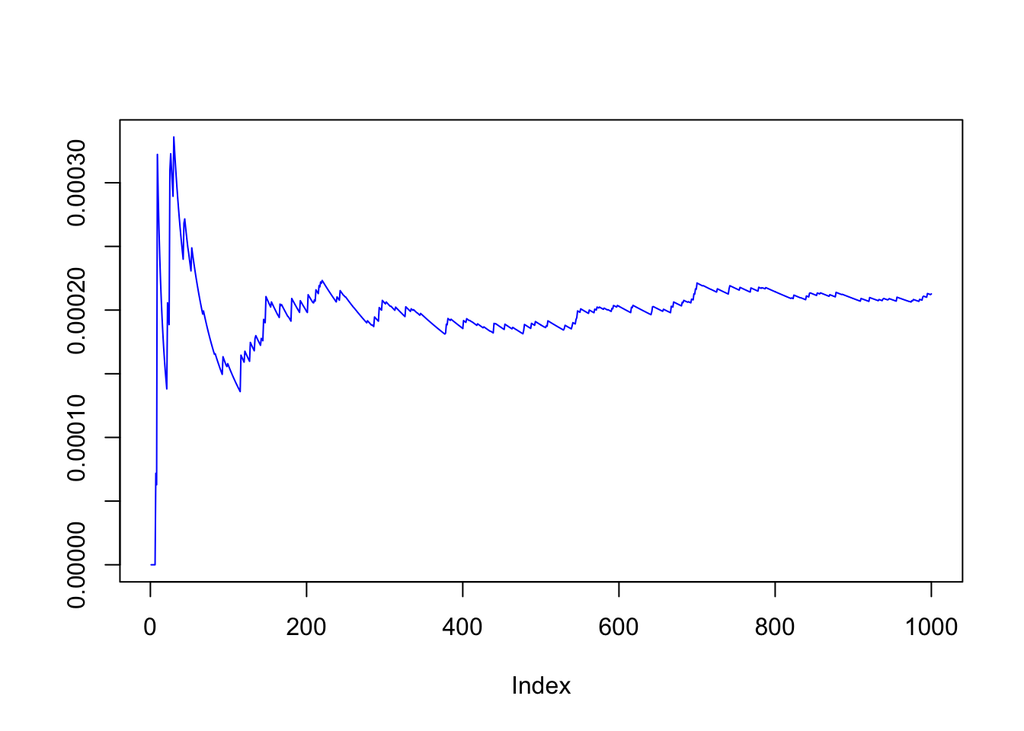

```r
p_x<-rnorm(1000,2.5,1)

sum<-0
for(i in 1:1000){
  if(p_x[i]>=3.5){
    p_x[i]=exp(2.5*(2.5-2*p_x[i])/(2*1))


  }else{
    p_x[i]=0
  }
}

Z_p=c()
for(i in 1:1000){
  Z_p=c(Z_p,mean(p_x[1:i]))
}


x<-rnorm(1000)
for(i in 1:1000){
  if(x[i]<3.5){
    x[i]=0
  }
}

Z_x=c()
for(i in 1:1000){
  Z_x=c(Z_x,mean(x[1:i]))
}





plot(Z_p,type='line',col='blue',ylab="")
```

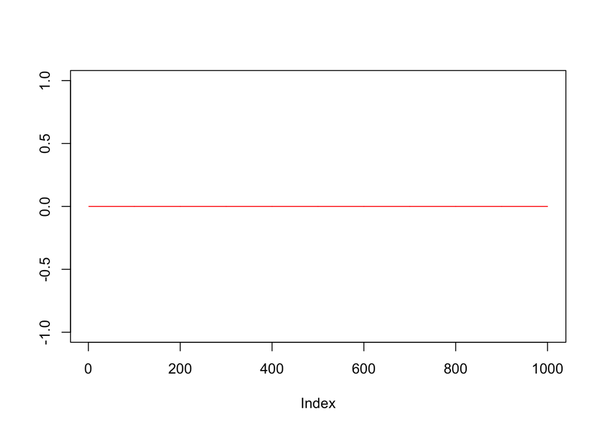

```r
plot(Z_x,type='line',col='red',ylab="")
```

La simulation pour un N élevé converge plus rapidement car sa variance est plus faible.

(e)PourN=1,…,10000,tracez sur une nouvelle fenêtre graphique la fonction N -> ψ(Z1μ)+…ψ(ZNμ) /N

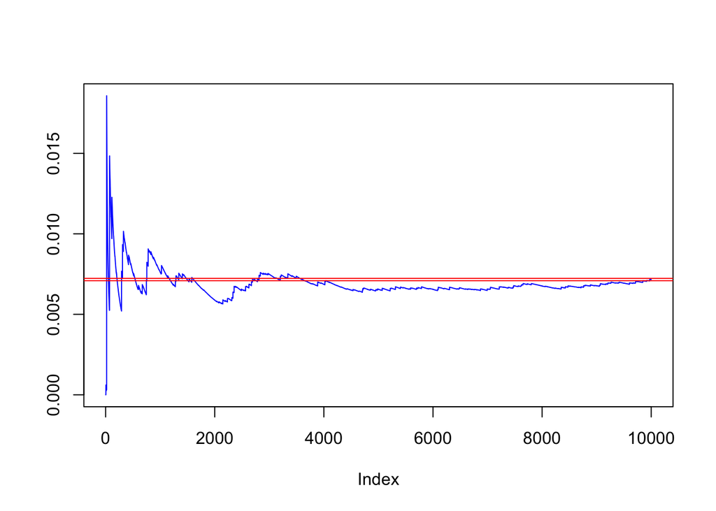

```r
p_x<-rnorm(10000,2.5,1)
sum<-0
for(i in 1:10000){
  mu<-6*runif(1,0,1)
  if(p_x[i]>=3.5){
  p_x[i]=exp(mu*(mu-2*p_x[i])/(2*1))
  }else{
    p_x[i]=0
  }

}

Z_p=c()
for(i in 1:10000){
  Z_p=c(Z_p,mean(p_x[1:i]))
}

Snx=0
for(i in 1:10000){
  Snx=Snx+p_x[i]^2+2*p_x[i]*Z_p[i]+Z_p[i]^2
}
Snx=Snx/9999
epsX=c_alpha*Snx/sqrt(10000)
plot(Z_p,type='line',col='blue',ylab="")

abline(h=Z_p[10000] +epsX,col='red')
abline(h=Z_p[10000] -epsX,col='red')
```

Ici on trouve que, a la fin, le résultat n’est pas dans l’intervalle de confiance avant un indice élevé, c’est peut-être car les points où (x>3.5) sont trop peu fréquents. Il termine toujours cependant par être dans l’intervalle de confiance.

# 4 On veut chercher le paramètre μ∗ qui minimise Eψ2(Zμ).

(a)Spécifiez la fonction K qui vérifie Eψ2(Zμ) = E(K(μ, ξ)), avec ξ ∼ N (0, 1)
$$\begin{aligned}
E(\psi^2(Z^{\mu}))&=E(\psi^2(\mu+\sigma\xi))) \\
&= E(g^2(\mu+\sigma\xi)exp(\frac{2\mu(\mu-2(\mu+\sigma\xi))}{2\sigma^2}))\\
&= \mathbb{E}K(\mu,\xi),\quad\xi\backsim N(0,1)\\
K(\mu,\xi)&=g^2(\mu+\sigma\xi)exp(\frac{2\mu(\mu-2(\mu+\sigma\xi))}{2\sigma^2})\\
&=g^2(\mu+\sigma\xi)exp(\frac{-2\mu^2-4\mu\sigma\xi}{2\sigma^2})\\
\end{aligned}$$
(b) Utilisez l’algorithme suivant pour donner une approximation de μ∗:
$$\begin{aligned}
K(\mu,\xi)&=g^2(\mu+\sigma\xi)exp(\frac{-2\mu^2-4\mu\sigma\xi}{2\sigma^2})\\
K'(\mu,\xi)&=2*g(\mu+\sigma\xi)*g'(\mu+\sigma\xi)exp(\frac{-2\mu^2-4\mu\sigma\xi}{2\sigma^2})+\\
& g^2(\mu+\sigma\xi)exp(\frac{-2\mu^2-4\mu\sigma\xi}{2\sigma^2})*(\frac{-4\mu-4\sigma\xi}{2\sigma^2})\\
K'(\mu,\xi)&=0 \quad if \quad \mu+\sigma\xi<3.5\\
K'(\mu,\xi)&=2*(\mu+\sigma\xi)exp(\frac{-2\mu^2-4\mu\sigma\xi}{2\sigma^2})+(\mu+\sigma\xi)^2exp(\frac{-2\mu^2-4\mu\sigma\xi}{2\sigma^2})*(\frac{-4\mu-4\sigma\xi}{2\sigma^2}) \quad if \quad \mu+\sigma\xi \ge 3.5
\end{aligned}$$

```r
K<-function(mu,delta,xi){

  if((mu+delta*xi)>=3.5){
  K=2*(mu+delta*xi)*exp((-2*mu^2-4*mu*delta*xi)/(2*delta^2)) +(mu+delta*xi)^2*exp((-2*mu^2-4*mu*delta*xi)/(2*delta^2))*(-4*mu-4*mu*delta*xi)/(2*delta^2)
  }else{
    K=0
  }
  return(K)

}


mu_esti<-runif(1,0,1)*6
for(i in 1:10000){
  xi=rnorm(1)


  mu_esti=mu_esti-(1/(i))*K(mu,1,xi)

}

mu_esti
```

```
## [1] 2.441336
```

3. Pour N = 1, . . . , 10000, tracez la fonction N,Comparez avec les résultats obtenus pour μ = 0 et μ = 2.5.

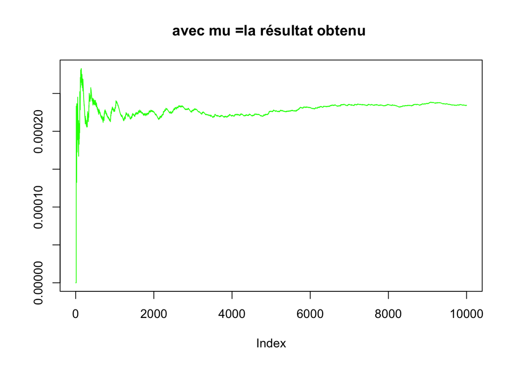

```r
p_x3<-rnorm(10000,mu_esti,1)
sum<-0
for(i in 1:10000){
  mu<-mu_esti
  if(p_x3[i]>=3.5){
  p_x3[i]=exp(mu*(mu-2*p_x3[i])/(2*1))
  }else{
    p_x3[i]=0
  }

}

Z_p3=c()
for(i in 1:10000){
  Z_p3=c(Z_p3,mean(p_x3[1:i]))
}
plot(Z_p3,type='line',col='green',ylab="",main="avec mu =la résultat obtenu ")
```